# Project Business Statistics: E-news Express

### Relationship between converted and time spent on the page

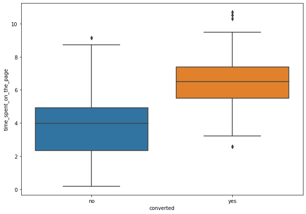

```python
plt.figure(figsize=(10,7))
sns.boxplot(data = df,  x ='converted', y = 'time_spent_on_the_page');
```

- The more the time spent on the page, the more users are converted,

### Relationship between language preferred and time spent on the page

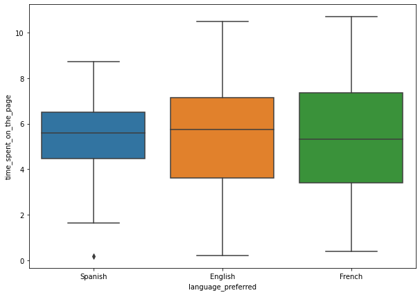

```python
plt.figure(figsize=(10,7))
sns.boxplot(data = df,  x ='language_preferred', y = 'time_spent_on_the_page');
```

## 1. Do the users spend more time on the new landing page than the existing landing page?

### Perform Visual Analysis

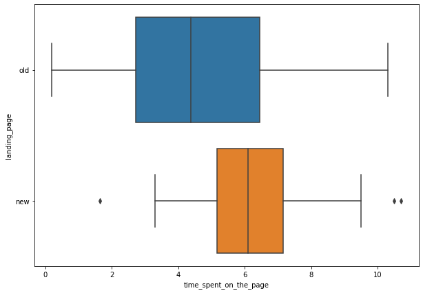

```python
# Descriptive analysis of time users spend on the new landing page and the existing landing page.
plt.figure(figsize=(10,7))
sns.boxplot(data = df,  x ='time_spent_on_the_page', y = 'landing_page');
```

- The Average time Users spend on the new landing page is more than that of the existing page but we confirm this with the inferential statistics.
- There are some (high time)outliers in the new landing page .

### Step 1: Define the null and alternate hypotheses

Let μe and μn be the mean time users stay on the existing and new landing pages respectively.

Testing the null hypothesis,

$H_0 :$ μn ≤ μe

Against the alternate hypothesis,

$H_a:$ μn > μe

### Step 2: Select Appropriate test

This is a one-tailed test concerning two population means from two independent populations with unknown standard deviations. Therefore the appropriate test to use will be a two sample independent t-test.

### Step 3: Decide the significance level

From the problem statement, level of significance is 5%. i,e $\alpha = 0.05$.

### Step 4: Collect and prepare data

```python
# Create new variables from the dataframe for time spent on the landing pages.
time_spent_new = df[df['landing_page'] == 'new']['time_spent_on_the_page']

# Create a subset of the dataframe for time spent on the existing landing page.
time_spent_existing = df[df['landing_page'] == 'old']['time_spent_on_the_page']
```

```python
# Get the standard deviations for the time spent on both pages.
print('The standard deviation for the time spent on the new landing page is:', round(time_spent_new.std(),2))
print('The standard deviation for the time spent on the existing landing page is:',  round(time_spent_existing.std(),2))
```

```
The standard deviation for the time spent on the new landing page is: 1.82
The standard deviation for the time spent on the existing landing page is: 2.58
```

Based on the figures obtained, the population standard deviations cannot be assumed to be equal for the new landing page and the existing page.

### Step 5: Calculate the p-value

```python
#import the required functions
from scipy.stats import ttest_ind


test_stat, p_value = ttest_ind(time_spent_new, time_spent_existing, equal_var = False, alternative = 'greater')
print('The p-value is ', p_value)
```

```
The p-value is  0.0001392381225166549
```

### Step 6: Compare the p-value with $\alpha$

```python
# Conclusion based on p-value obtained
if p_value < 0.05:
    print(f'As the p-value {p_value} is less than the level of significance, we reject the null hypothesis.')
else:
    print(f'As the p-value {p_value} is greater than the level of significance, we fail to reject the null hypothesis.')
```

```
As the p-value 0.0001392381225166549 is less than the level of significance, we reject the null hypothesis.
```

### Step 7: Draw inference

As the p-value is less than the level of significance $\alpha$, we reject the null hypothesis and hence conclude that we have enough statistical evidence to support the claim that the average time users stay on the new landing page is greater than the average time users stay on the existing or old landing page which also confirms the result from the descriptive analysis.

## 2. Is the conversion rate (the proportion of users who visit the landing page and get converted) for the new page greater than the conversion rate for the old page?

### Perform Visual Analysis

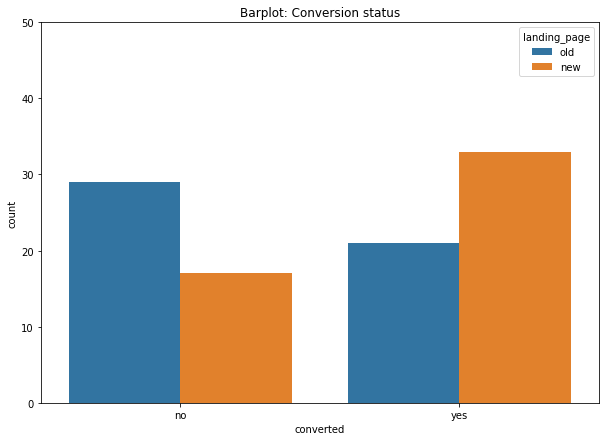

```python
# Plot of existing landing page and the new landing page with the conversion status.
plt.figure(figsize=(10,7))
plt.title('Barplot: Conversion status')
plt.ylim(0,50)
sns.countplot(data=df, x='converted',hue='landing_page')
plt.xlabel('converted')
plt.show()
```

- More users got converted from the new landing page than the old(existing) landing page. We will also confirm this from inferential statistics.

#### Define the null and alternate hypothesis

Let Pe and Pn be the conversion proportions for the existing and new landing pages respectively.

Testing the null hypothesis,

$H_0 :$ Pn ≤ Pe

Against the alternate hypothesis,

$H_a:$ Pn > Pe

### Select appropriate test

This is a one-tailed test concerning two population proportions from two independent populations. Therefore the two proportion z-test will be the appropriate test to use.

### Decide the level of significance

From the problem statement, level of significance is 5%. i,e $\alpha = 0.05$.

### Collect and prepare data

```python
# Number of converted users in the new page(Treatment group)
converted_new = df[df['group']=='treatment']['converted'].value_counts().yes
# Number of converted users in the existing page(control group)
converted_old = df[df['group']== 'control']['converted'].value_counts().yes

# Total number of users in the treatment group
treatment_total = df['group'].value_counts().treatment
# Total number of users in the control group
control_total = df['group'].value_counts().control

print('The numbers of users for the new and existing pages are {0} and {1} respectively'.format(treatment_total , control_total) )
```

```
The numbers of users for the new and existing pages are 50 and 50 respectively
```

### Calculate the p-value

```python
# import the required fuction
from statsmodels.stats.proportion import proportions_ztest


test_stat, p_value = proportions_ztest([converted_new,converted_old], [treatment_total,control_total], value= 0 , alternative = 'larger')
print('The p-value is ' + str(p_value))
print('The test_stat is ' + str(test_stat))
```

```
The p-value is 0.008026308204056278
The test_stat is 2.4077170617153842
```

### Compare the p-value with $\alpha$

```python
# conclusion based on p-value
if p_value < 0.05:
    print(f'As the p-value {p_value} is less than the level of significance, we reject the null hypothesis.')
else:
    print(f'As the p-value {p_value} is greater than the level of significance, we fail to reject the null hypothesis.')
```

```
As the p-value 0.008026308204056278 is less than the level of significance, we reject the null hypothesis.
```

# Draw inference

Since the p-value is less than the level of significance $\alpha$, we reject the null hypothesis and hence conclude that we have enough statistical evidence that the proportion of users that got converted while visiting the new landing page(treatment) is more than that of the existing page(control) which also validates the descriptive analysis.

## 3. Is the conversion and preferred language are independent or related?

### Perform visual analysis

```python
# create a contingency table to tabulate the frequencies of the two categorical variables.
pd.crosstab(df['converted'],df['language_preferred'], margins= True)
```

| language_preferred converted | English | French | Spanish | All |
| --- | --- | --- | --- | --- |
| no | 11 | 19 | 16 | 46 |
| yes | 21 | 15 | 18 | 54 |
| All | 32 | 34 | 34 | 100 |

- Total of 100 samples collected.
- More users get converted from the English language option that the other two languages, about 66% even though the number of English language users is slightly lower than the other two.
- Convertion rate from the French language option is 44% while the convertion rate from the Spanish language option is 53%.

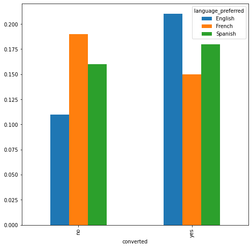

```python
# visual analysis
pd.crosstab(df['converted'],df['language_preferred'], normalize=True).plot(kind='bar', figsize=(8,8))
plt.show()
```

- The proportion of users that get converted is highest for the English Language option based on visual analysis but we will confirm from inferential analysis if this proportion really depends on the language.

### Define the null and alternate hypothesis

$H_0:$ Converted status is independent on the preferred language .

$H_a:$ Converted status is dependent on the preferred language.

### Select the appropriate test

This is a frequency test concerning two independent categorical variables, converted status and language preferred. Therefore the Chi-square test for independence is the appropriate test to use.

### Decide the level of significance

From the problem statement, level of significance is 5%. i,e $\alpha = 0.05$.

### Collect and prepare data

```python
# Create a variable for the contingency table as an input in calculating the p-value.
contingency_table =  pd.crosstab(df['converted'],df['language_preferred'])
contingency_table
```

| language_preferred converted | English | French | Spanish |
| --- | --- | --- | --- |
| no | 11 | 19 | 16 |
| yes | 21 | 15 | 18 |

### Calculate the p-value

```python
# import the required test function
from scipy.stats import chi2_contingency


chi, p_value, dof, expected = chi2_contingency(contingency_table)

print("p-value =",p_value)
```

```
p-value = 0.21298887487543447
```

### Compare the p-value with $\alpha$

```python
# Conclusion based on p-value
if p_value < 0.05:
    print(f'As the p-value {p_value} is less than the level of significance, we reject the null hypothesis.')
else:
    print(f'As the p-value {p_value} is greater than the level of significance, we fail to reject the null hypothesis.')
```

```
As the p-value 0.21298887487543447 is greater than the level of significance, we fail to reject the null hypothesis.
```

### Draw Inference

Since the p-value is larger than the level of significance $\alpha$,we fail to reject the null hypothesis. Hence we do not have enough statistical evidence to conclude that converted status is not independent on the preferred language which also means the outcome from the visual analysis is not conclusive.

## 4. Is the time spent on the new page same for the different language users?

### Perform Visual Analysis

```python
# Create a new dataframe to get the users who got the new page.
df_new = df[df['landing_page']== 'new']
df_new.head()
```

|  | user_id | group | landing_page | time_spent_on_the_page | converted | language_preferred |
| --- | --- | --- | --- | --- | --- | --- |
| 1 | 546468 | treatment | new | 7.13 | yes | English |
| 2 | 546462 | treatment | new | 4.40 | no | Spanish |
| 4 | 546459 | treatment | new | 4.75 | yes | Spanish |
| 6 | 546448 | treatment | new | 5.25 | yes | French |
| 8 | 546461 | treatment | new | 10.71 | yes | French |

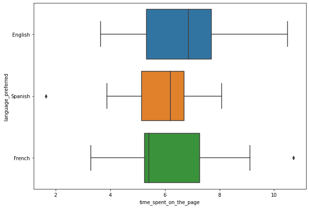

```python
# Plot of the time spent on this new page with the preferred language
plt.figure(figsize=(10,7))
sns.boxplot(data=df_new, x= 'time_spent_on_the_page', y='language_preferred')
plt.show()
```

- The average time spent on the new page for the languages is different with English langauge users spending the highest time .
- There are some outliers in the spanish and french users,

### Define the null and alternate hypothesis

Let μe , μs and μf be the means of the time spent on the new page for English , Spanish and French users respectively.

Testing the null hypothesis,

$H_0 :$ μe = μs = μf

Against the alternate hypothesis,

$H_a:$ At least one of the mean time spent on the new page is different.

### Select the appropriate test

This is a problem dealing with three independent population means. Therefore one_way Anova test is the appropriate test to use.

### Decide the level of significance

From the problem statement, level of significance is 5%. i,e $\alpha = 0.05$.

### Collect and prepare data.

```python
# Subset dataframe for the time spent on the new page by English language users.
English_users = df_new[df_new['language_preferred']== 'English']['time_spent_on_the_page']
#Subset dataframe for the time spent on the new page by Spanish language users.
Spanish_users = df_new[df_new['language_preferred']== 'Spanish']['time_spent_on_the_page']
#Subset dataframe for the time spent on the new page by French language users.
French_users = df_new[df_new['language_preferred']== 'French']['time_spent_on_the_page']
```

The normality and equality of variance assumptions for one_way Anova needs to be checked.

- For testing of normality, Shapiro-Wilk’s test is applied.
- For equality of variance, Levene test is applied.

### Shapiro-Wilk’s test

We will test the null hypothesis

> $H_0:$ Time spent on new page follows a normal distribution

against the alternative hypothesis

> $H_a:$ Time spent on new page does not follow a normal distribution

```python
# import the required function
from scipy import stats

w, p_value = stats.shapiro(df_new['time_spent_on_the_page'])
print('The p-value is', p_value)
```

```
The p-value is 0.8040016293525696
```

Since p-value of the test is very large, we fail to reject the null hypothesis that the response variable(time_spent_on_the_page) follows the normal distribution.

### Levene’s test

We will test the null hypothesis

> $H_0$: All the population variances are equal

against the alternative hypothesis

> $H_a$: At least one variance is different from the rest

```python
#import the required function
from scipy.stats import levene
statistic, p_value = levene( English_users,
                            Spanish_users,
                            French_users)

print('The p-value is', p_value)
```

```
The p-value is 0.46711357711340173
```

Since the p-value is large than the 5% significance level, we fail to reject the null hypothesis that the population variances are equal.

### Calculate the p-value

```python
from scipy.stats import f_oneway

test_stat, p_value = f_oneway( English_users,
                            Spanish_users,
                            French_users)
print('The p-value is ' + str(p_value))
```

```
The p-value is 0.43204138694325955
```

### Compare the p-value with $\alpha$

```python
# Conclusion based on p-value
if p_value < 0.05:
    print(f'As the p-value {p_value} is less than the level of significance, we reject the null hypothesis.')
else:
    print(f'As the p-value {p_value} is greater than the level of significance, we fail to reject the null hypothesis.')
```

```
As the p-value 0.43204138694325955 is greater than the level of significance, we fail to reject the null hypothesis.
```

### Draw Inference

Since the p-value is greater that the level of significance $\alpha$, we fail to reject the null hypothesis. Hence we do not have enough statistical evidence to conclude that the average time spent on the new page for the different language users is different which does not agree with the visual analysis.

## Conclusion and Business Recommendations

### Conclusion

*50% of users spend at least 5.41 minutes on average on the landing page which is also equivalent to the average time users spend on the landing page.

*From visual analytics and inferential statistics, it is confirmed that the average time users stay on the new landing page(Treatment) is more than the average time users stay on the existing landing page(Control).